# Phân tích chuỗi thời gian

**Biên soạn**

ThS. Nguyễn Tấn Đức | [www.tuhocr.com](https://www.tuhocr.com/)

**Cập nhật**

2024 June 06

**Dữ liệu mã chứng khoán trong file này được mô phỏng giả lập trên máy tính, mục đích để minh họa cách phân tích chuỗi thời gian.**

https://applyr.netlify.app/codebase/timeseries/timeseries.rar

# 1 Time series patterns

https://otexts.com/fpp3/tspatterns.html

# 2 Import dataset

**Đề bài: Dự báo 15 phiên tiếp theo so sánh với thực tế xảy ra sử dụng ARIMA**

```r
library(dplyr)
library(ggplot2)
library(readxl)
GHZ <- read_excel("GHZ.xlsx")
GHZ <- as.data.frame(GHZ)
head(GHZ)
```

```
        DATE PRICE
1 29/02/2024 22750
2 28/02/2024 22900
3 27/02/2024 22850
4 26/02/2024 22450
5 23/02/2024 22150
6 22/02/2024 22550
```

# 3 Check dataset

```r
# dim(GHZ)
# class(GHZ$DATE)
# class(GHZ$PRICE)
# head(GHZ)
summary(GHZ)
```

```
     DATE               PRICE
 Length:287         Min.   :11990
 Class :character   1st Qu.:15388
 Mode  :character   Median :17750
                    Mean   :18198
                    3rd Qu.:21475
                    Max.   :23550
```

```r
# str(GHZ)
# any(is.na(GHZ))
```

# 4 Convert datetime vector

```r
GHZ$DATE <- as.Date(GHZ$DATE, format = "%d/%m/%Y")
```

# 5 Plot timeseries

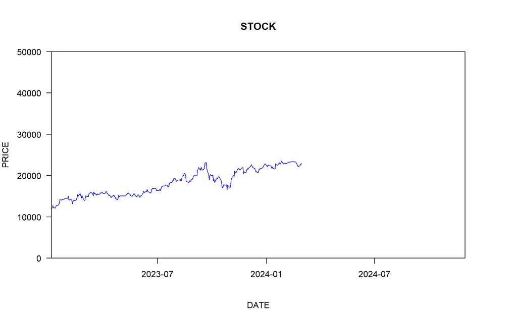

```r
par(mar = c(5, 5, 5, 5))
par(mgp = c(4, 1, 0))

plot(PRICE ~ DATE, data = GHZ,
     type = "l",
     col = "blue",
     ylim = c(0, 50000),
     xlim = c(as.Date("2023-01-03"),
              as.Date("2024-12-01")),
     xaxs = "i",
     yaxs = "i",
     las = 1,
     main = "STOCK")
```

# 6 Forcast cho `GHZ`

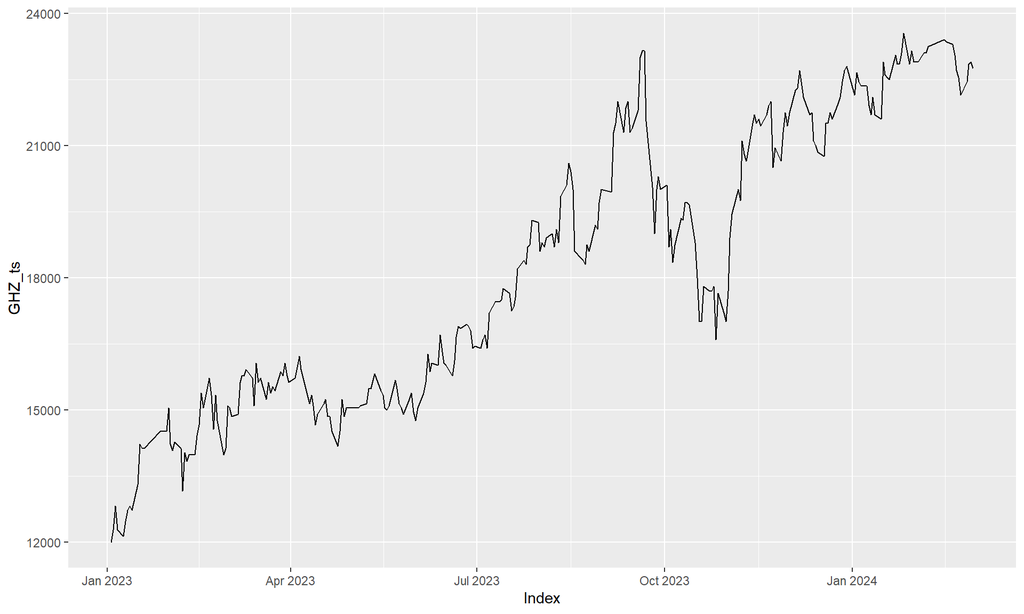

```r
library(zoo)
GHZ_ts <- read.zoo(GHZ)
zoo:::autoplot.zoo(GHZ_ts)
```

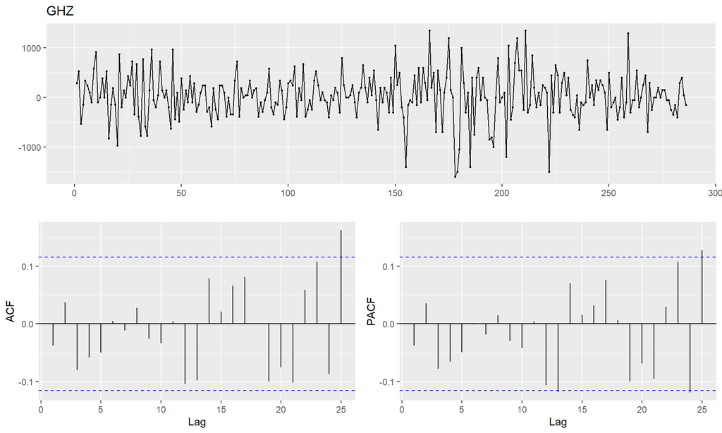

```r
# autoplot(GHZ_ts)

library(fpp2)
GHZ_ts %>% diff() %>% ggtsdisplay(main = "GHZ")
```

## 6.1 Phân tích ARIMA cho `GHZ`

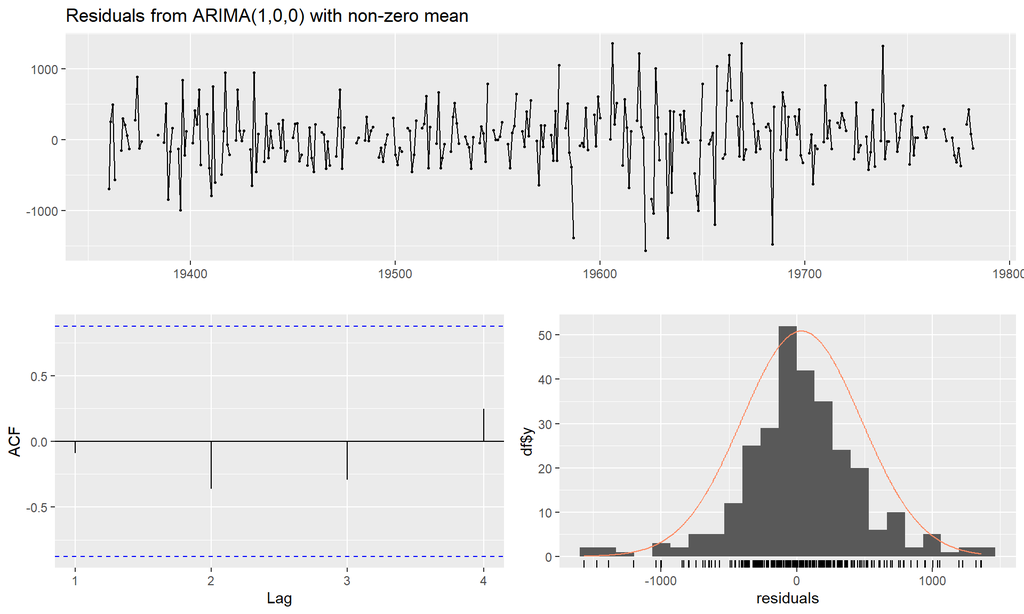

```
    Ljung-Box test

data:  Residuals from ARIMA(1,0,0) with non-zero mean
Q* = 20.067, df = 9, p-value = 0.0175

Model df: 1.   Total lags used: 10
```

```r
### chạy mô hình ARIMA ### chú ý season, các tham số ở order
fit_GHZ <- Arima(GHZ_ts, order = c(1, 0, 0))
checkresiduals(fit_GHZ)
```

```r
### set ngày dự đoán
dudoan <- 15

ketqua_GHZ <- forecast(fit_GHZ, h = dudoan)
predict(fit_GHZ, n.ahead = dudoan)
```

```
$pred
Time Series:
Start = 19783
End = 19797
Frequency = 1
 [1] 22720.75 22691.68 22662.80 22634.10 22605.58 22577.25 22549.09 22521.12 22493.32 22465.70
[11] 22438.25 22410.98 22383.88 22356.96 22330.20

$se
Time Series:
Start = 19783
End = 19797
Frequency = 1
 [1]  443.7371  625.5483  763.7118  879.0728  979.7354 1069.8707 1151.9656 1227.6462 1298.0463
[10] 1363.9943 1426.1180 1484.9070 1540.7521 1593.9713 1644.8278
```

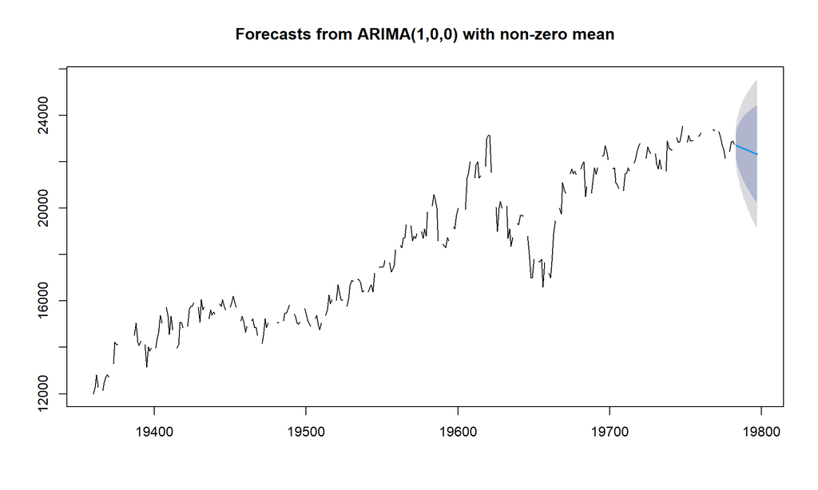

```r
forecast:::plot.forecast(ketqua_GHZ, showgap = TRUE)
```

```r
source("forcast_data.R")

par(mar = c(5, 5, 5, 5))
forcast_data(ketqua_GHZ, xaxt = "n",
             showgap = FALSE,
             main = "GHZ",
             xlab = "DATE",
             ylab = "PRICE",
             las = 2,
             ylim = c(0, 50000))

head(all_date)
```

```
[1] "2023-01-03" "2023-01-04" "2023-01-05" "2023-01-06" "2023-01-07" "2023-01-08"
```

```r
tail(all_date)
```

```
[1] "2024-03-11" "2024-03-12" "2024-03-13" "2024-03-14" "2024-03-15" "2024-03-16"
```

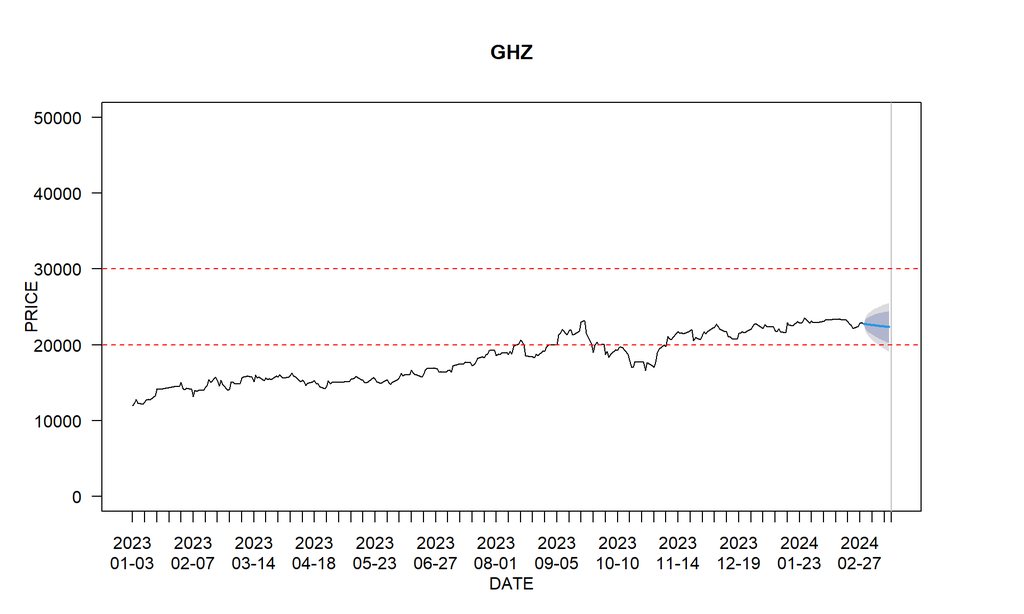

```r
labels_ok <- seq(as.Date(all_date)[1], as.Date(all_date)[length(all_date)], by = "weeks")

axis(side = 1,
     at = c(seq(as.Date(all_date)[1], as.Date(all_date)[length(all_date)], by = "weeks"), as.Date(all_date)[length(all_date)]),
     labels = c(format(labels_ok, format="%Y\n%m-%d"),
                format(as.Date(all_date)[length(all_date)], format="%Y\n%m-%d")),
     # col.ticks = NA,
     col.axis = NA,
     # col = NA
     # line = 2
)

axis(side = 1,
     at = c(seq(as.Date(all_date)[1], as.Date(all_date)[length(all_date)], by = "weeks"), as.Date(all_date)[length(all_date)]),
     labels = c(format(labels_ok, format="%Y\n%m-%d"),
                format(as.Date(all_date)[length(all_date)], format="%Y\n%m-%d")),
     col.ticks = NA,
     col.axis = "black",
     cex.axis = 1,
     col = NA,
     line = 1)

abline(v = as.Date(all_date)[length(all_date)], col = "gray")
abline(h = 20000, col = "red", lty = 2)
abline(h = 30000, col = "red", lty = 2)
```

## 6.2 Đối chiếu với kết quả thực tế `GHZ`

```r
GHZ_BS15 <- read_excel("GHZ_BS15.xlsx")
GHZ_BS15 <- as.data.frame(GHZ_BS15)
GHZ_BS15$DATE <- as.Date(GHZ_BS15$DATE, format = "%d/%m/%Y")

GHZ_thucte <- GHZ_BS15 |> subset(DATE <= as.Date("2024-03-15"))

GHZ_thucte <- rbind(GHZ_thucte, GHZ[1, ])
```

```r
par(mar = c(5, 5, 5, 5))
par(mgp = c(4, 1, 0))

forcast_data(ketqua_GHZ, xaxt = "n", yaxt = "n",
             showgap = FALSE,
             main = "GHZ",
             # shaded = FALSE,
             # pi.col = "purple",
             shadecols = "gray80",
             xlab = "DATE",
             ylab = "PRICE",
             fcol = "blue",
             las = 2,
             xlim = c(as.numeric(as.Date("2024-02-27")), as.numeric(as.Date("2024-03-15"))),
             ylim = c(10000, 30000))

head(all_date)
```

```
[1] "2023-01-03" "2023-01-04" "2023-01-05" "2023-01-06" "2023-01-07" "2023-01-08"
```

```r
tail(all_date)
```

```
[1] "2024-03-11" "2024-03-12" "2024-03-13" "2024-03-14" "2024-03-15" "2024-03-16"
```

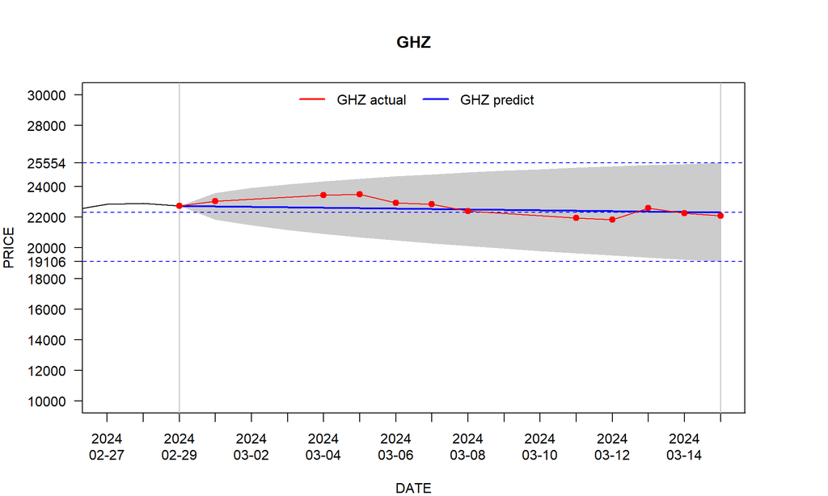

```r
labels_ok <- seq(as.Date(all_date)[1], as.Date(all_date)[length(all_date)], by = "days")

axis(side = 1,
     at = c(seq(as.Date(all_date)[1], as.Date(all_date)[length(all_date)], by = "days"), as.Date(all_date)[length(all_date)]),
     labels = c(format(labels_ok, format="%Y\n%m-%d"),
                format(as.Date(all_date)[length(all_date)], format="%Y\n%m-%d")),
     # col.ticks = NA,
     col.axis = NA,
     # col = NA
     # line = 2
)

axis(side = 1,
     at = c(seq(as.Date(all_date)[1], as.Date(all_date)[length(all_date)], by = "days"), as.Date(all_date)[length(all_date)]),
     labels = c(format(labels_ok, format="%Y\n%m-%d"),
                format(as.Date(all_date)[length(all_date)], format="%Y\n%m-%d")),
     col.ticks = NA,
     col.axis = "black",
     cex.axis = 1,
     col = NA,
     line = 1)

abline(v = as.Date("2024-02-29"), col = "gray")
abline(v = as.Date("2024-03-15"), col = "gray")

abline(h = ketqua_GHZ$mean[length(ketqua_GHZ$mean)],
       col = "blue", lty = 2)

abline(h = ketqua_GHZ$upper[nrow(ketqua_GHZ$upper), 2],
       col = "blue", lty = 2)
abline(h = ketqua_GHZ$lower[nrow(ketqua_GHZ$lower), 2],
       col = "blue", lty = 2)

axis(side = 2,
     at = round(c(10000, 12000, 14000, 16000, 18000,
                  ketqua_GHZ$lower[nrow(ketqua_GHZ$lower), 2],
            20000, 22000, 24000, ketqua_GHZ$upper[nrow(ketqua_GHZ$upper), 2],
            28000, 30000), digits = 0),
     las = 2)

points(GHZ_thucte$PRICE ~ GHZ_thucte$DATE,
       type = "o",
       col = "red",
       pch = 19)

legend(x = "top",
       y = NULL,
       legend = c("GHZ actual", "GHZ predict"),
       col = c("red", "blue"),
       lwd = 2,
       horiz = TRUE,
       bty = "n")
```

## 6.3 Kiểm định thống kê kết quả dự đoán `GHZ`

**Để thực hiện t-test paired ta cần xếp lại dữ liệu khớp ngày tháng**

```r
unclass(ketqua_GHZ$mean) -> dudoan_GHZ_check
attributes(dudoan_GHZ_check)$tsp[1:2] -> date_GHZ_check

date_begin <- as.POSIXct.numeric(date_GHZ_check[1] * 24 * 3600)
date_end <- as.POSIXct.numeric(date_GHZ_check[2] * 24 * 3600)
date_begin <- as.Date(date_begin)
date_end <- as.Date(date_end)

date_GHZ_check_ok <- seq(from = date_begin, to = date_end, by = "days")

df_dudoan_GHZ <- data.frame(DATE = date_GHZ_check_ok, PRICE = dudoan_GHZ_check)

GHZ_compare <- merge(x = df_dudoan_GHZ,
                     y = GHZ_thucte,
                     by = "DATE",
                     all = TRUE)

names(GHZ_compare)[2:3] <- c("PRICE_dudoan", "PRICE_thucte")

GHZ_compare
```

```
         DATE PRICE_dudoan PRICE_thucte
1  2024-02-29           NA        22750
2  2024-03-01     22720.75        23050
3  2024-03-02     22691.68           NA
4  2024-03-03     22662.80           NA
5  2024-03-04     22634.10        23450
6  2024-03-05     22605.58        23500
7  2024-03-06     22577.25        22950
8  2024-03-07     22549.09        22850
9  2024-03-08     22521.12        22400
10 2024-03-09     22493.32           NA
11 2024-03-10     22465.70           NA
12 2024-03-11     22438.25        21950
13 2024-03-12     22410.98        21850
14 2024-03-13     22383.88        22600
15 2024-03-14     22356.96        22250
16 2024-03-15     22330.20        22100
```

```r
GHZ_compare_clean <- na.omit(GHZ_compare)

GHZ_compare_clean
```

```
         DATE PRICE_dudoan PRICE_thucte
2  2024-03-01     22720.75        23050
5  2024-03-04     22634.10        23450
6  2024-03-05     22605.58        23500
7  2024-03-06     22577.25        22950
8  2024-03-07     22549.09        22850
9  2024-03-08     22521.12        22400
12 2024-03-11     22438.25        21950
13 2024-03-12     22410.98        21850
14 2024-03-13     22383.88        22600
15 2024-03-14     22356.96        22250
16 2024-03-15     22330.20        22100
```

**Kiểm tra giả thuyết cho t-test**

```r
### giả thuyết về phân bố chuẩn
### p-value > 0.5 là phân bố chuẩn
shapiro.test(GHZ_compare_clean$PRICE_thucte)
```

```
    Shapiro-Wilk normality test

data:  GHZ_compare_clean$PRICE_thucte
W = 0.94507, p-value = 0.5818
```

```r
shapiro.test(GHZ_compare_clean$PRICE_dudoan)
```

```
    Shapiro-Wilk normality test

data:  GHZ_compare_clean$PRICE_dudoan
W = 0.95492, p-value = 0.7072
```

```r
### giả thuyết về phương sai đồng dạng
### p-value > 0.5 là phương sai đồng dạng
var.test(GHZ_compare_clean$PRICE_thucte, GHZ_compare_clean$PRICE_dudoan)
```

```
    F test to compare two variances

data:  GHZ_compare_clean$PRICE_thucte and GHZ_compare_clean$PRICE_dudoan
F = 20.52, num df = 10, denom df = 10, p-value = 4.663e-05
alternative hypothesis: true ratio of variances is not equal to 1
95 percent confidence interval:
  5.521004 76.270138
sample estimates:
ratio of variances
          20.52042
```

**Thực hiện kiểm định t-test paired**

```r
t.test(x = GHZ_compare_clean$PRICE_thucte,
       y = GHZ_compare_clean$PRICE_dudoan,
       paired = TRUE,
       var.equal = FALSE,
       conf.level = 0.95,
       alternative = "two.sided"
       )
```

```
    Paired t-test

data:  GHZ_compare_clean$PRICE_thucte and GHZ_compare_clean$PRICE_dudoan
t = 0.89416, df = 10, p-value = 0.3922
alternative hypothesis: true mean difference is not equal to 0
95 percent confidence interval:
 -192.8381  451.3540
sample estimates:
mean difference
        129.258
```

**Thực hiện kiểm định t-test cho `d` khoảng chênh lệch**

```r
d <- abs(GHZ_compare_clean$PRICE_thucte - GHZ_compare_clean$PRICE_dudoan)

t.test(d, mu = 0,
       conf.level = 0.95,
       alternative = "two.sided"
       )
```

```
    One Sample t-test

data:  d
t = 5.0822, df = 10, p-value = 0.0004762
alternative hypothesis: true mean is not equal to 0
95 percent confidence interval:
 226.5147 580.1855
sample estimates:
mean of x
 403.3501
```

**Kết luận: Khi dự đoán sơ bộ bằng mô hình ARIMA cho GHZ (chưa kiểm tra về season, hay các kiểm định tính dừng, chuỗi trượt…) ta thu được giá trị dự đoán cho 15 ngày từ 1/3 đến 15/3/2024 có sự chênh lệch dữ liệu thực tế là 403 VNĐ (khoảng tin cậy 95%: từ 227 đến 580 VNĐ).**

# 7 Đường trung bình động/trượt (moving average)

A moving average is a commonly used technique for analyzing time series data.

It helps smooth out short-term fluctuations and highlight underlying trends or patterns in the data.

The concept of a moving average involves calculating the average of a subset of data points within a specified window and moving that window along the time series.

```r
library(quantmod)

# AAPL (Apple Corporation)
# quantmod::getSymbols("AAPL",
#            src = 'yahoo',
#            from = as.Date('2021-01-01'))

# saveRDS(AAPL, "AAPL.rds")
AAPL <- readRDS("AAPL.rds")
```

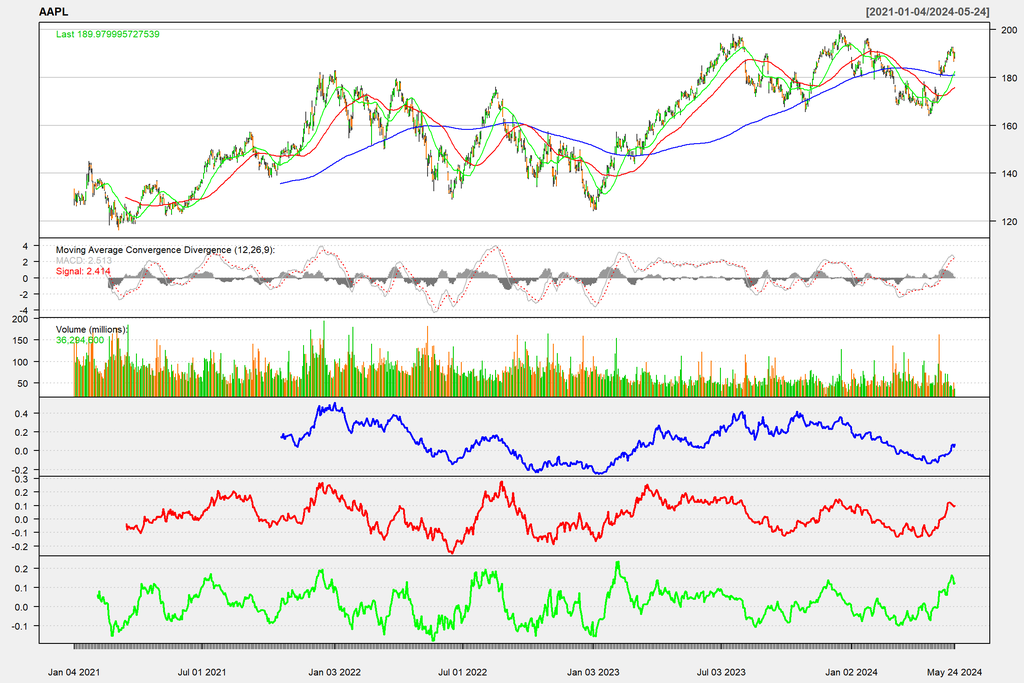

```r
quantmod::chartSeries(AAPL,
            theme = 'white',
            type = c("auto", "matchsticks"),
            subset = '2021-01::', # define a time range subset
            show.grid = TRUE,
            major.ticks='auto',
            minor.ticks=TRUE,
            multi.col = FALSE,
            TA=c(addMACD(),
                 addVo(),
                 addSMA(n=200,col = 'blue'), # add moving average of ‘n’ periods
                 addSMA(n=50,col = 'red'),
                 addSMA(n=22,col = 'green'),
                 addROC(n=200,col = 'blue'), # Add Rate Of Change indicator to chart
                 addROC(n=50,col = 'red'),
                 addROC(n=22,col = 'green')) # a vector of technical indicators and params, or character strings
            )
```

# 8 Lệnh `lag()` trong R

Lệnh `lag()` dùng để thay đổi mốc thời gian trong bộ dữ liệu, sử dụng cho việc tính trung bình cho từng khoảng thời gian khác nhau khi phân tích time series.

## 8.1 Lệnh `lag()` áp dụng cho `ts` object ở dạng matrix

```r
ts_year <- stats::ts(data = 1:20,
                     frequency = 12,
                     start = 2001,
                     end = 2020)

ts_year
```

```
     Jan Feb Mar Apr May Jun Jul Aug Sep Oct Nov Dec
2001   1   2   3   4   5   6   7   8   9  10  11  12
2002  13  14  15  16  17  18  19  20   1   2   3   4
2003   5   6   7   8   9  10  11  12  13  14  15  16
2004  17  18  19  20   1   2   3   4   5   6   7   8
2005   9  10  11  12  13  14  15  16  17  18  19  20
2006   1   2   3   4   5   6   7   8   9  10  11  12
2007  13  14  15  16  17  18  19  20   1   2   3   4
2008   5   6   7   8   9  10  11  12  13  14  15  16
2009  17  18  19  20   1   2   3   4   5   6   7   8
2010   9  10  11  12  13  14  15  16  17  18  19  20
2011   1   2   3   4   5   6   7   8   9  10  11  12
2012  13  14  15  16  17  18  19  20   1   2   3   4
2013   5   6   7   8   9  10  11  12  13  14  15  16
2014  17  18  19  20   1   2   3   4   5   6   7   8
2015   9  10  11  12  13  14  15  16  17  18  19  20
2016   1   2   3   4   5   6   7   8   9  10  11  12
2017  13  14  15  16  17  18  19  20   1   2   3   4
2018   5   6   7   8   9  10  11  12  13  14  15  16
2019  17  18  19  20   1   2   3   4   5   6   7   8
2020   9
```

```r
stats::lag(ts_year, k = 1)
```

```
     Jan Feb Mar Apr May Jun Jul Aug Sep Oct Nov Dec
2000                                               1
2001   2   3   4   5   6   7   8   9  10  11  12  13
2002  14  15  16  17  18  19  20   1   2   3   4   5
2003   6   7   8   9  10  11  12  13  14  15  16  17
2004  18  19  20   1   2   3   4   5   6   7   8   9
2005  10  11  12  13  14  15  16  17  18  19  20   1
2006   2   3   4   5   6   7   8   9  10  11  12  13
2007  14  15  16  17  18  19  20   1   2   3   4   5
2008   6   7   8   9  10  11  12  13  14  15  16  17
2009  18  19  20   1   2   3   4   5   6   7   8   9
2010  10  11  12  13  14  15  16  17  18  19  20   1
2011   2   3   4   5   6   7   8   9  10  11  12  13
2012  14  15  16  17  18  19  20   1   2   3   4   5
2013   6   7   8   9  10  11  12  13  14  15  16  17
2014  18  19  20   1   2   3   4   5   6   7   8   9
2015  10  11  12  13  14  15  16  17  18  19  20   1
2016   2   3   4   5   6   7   8   9  10  11  12  13
2017  14  15  16  17  18  19  20   1   2   3   4   5
2018   6   7   8   9  10  11  12  13  14  15  16  17
2019  18  19  20   1   2   3   4   5   6   7   8   9
```

```r
stats::lag(ts_year, k = 0)
```

```
     Jan Feb Mar Apr May Jun Jul Aug Sep Oct Nov Dec
2001   1   2   3   4   5   6   7   8   9  10  11  12
2002  13  14  15  16  17  18  19  20   1   2   3   4
2003   5   6   7   8   9  10  11  12  13  14  15  16
2004  17  18  19  20   1   2   3   4   5   6   7   8
2005   9  10  11  12  13  14  15  16  17  18  19  20
2006   1   2   3   4   5   6   7   8   9  10  11  12
2007  13  14  15  16  17  18  19  20   1   2   3   4
2008   5   6   7   8   9  10  11  12  13  14  15  16
2009  17  18  19  20   1   2   3   4   5   6   7   8
2010   9  10  11  12  13  14  15  16  17  18  19  20
2011   1   2   3   4   5   6   7   8   9  10  11  12
2012  13  14  15  16  17  18  19  20   1   2   3   4
2013   5   6   7   8   9  10  11  12  13  14  15  16
2014  17  18  19  20   1   2   3   4   5   6   7   8
2015   9  10  11  12  13  14  15  16  17  18  19  20
2016   1   2   3   4   5   6   7   8   9  10  11  12
2017  13  14  15  16  17  18  19  20   1   2   3   4
2018   5   6   7   8   9  10  11  12  13  14  15  16
2019  17  18  19  20   1   2   3   4   5   6   7   8
2020   9
```

```r
stats::lag(ts_year, k = -1)
```

```
     Jan Feb Mar Apr May Jun Jul Aug Sep Oct Nov Dec
2001       1   2   3   4   5   6   7   8   9  10  11
2002  12  13  14  15  16  17  18  19  20   1   2   3
2003   4   5   6   7   8   9  10  11  12  13  14  15
2004  16  17  18  19  20   1   2   3   4   5   6   7
2005   8   9  10  11  12  13  14  15  16  17  18  19
2006  20   1   2   3   4   5   6   7   8   9  10  11
2007  12  13  14  15  16  17  18  19  20   1   2   3
2008   4   5   6   7   8   9  10  11  12  13  14  15
2009  16  17  18  19  20   1   2   3   4   5   6   7
2010   8   9  10  11  12  13  14  15  16  17  18  19
2011  20   1   2   3   4   5   6   7   8   9  10  11
2012  12  13  14  15  16  17  18  19  20   1   2   3
2013   4   5   6   7   8   9  10  11  12  13  14  15
2014  16  17  18  19  20   1   2   3   4   5   6   7
2015   8   9  10  11  12  13  14  15  16  17  18  19
2016  20   1   2   3   4   5   6   7   8   9  10  11
2017  12  13  14  15  16  17  18  19  20   1   2   3
2018   4   5   6   7   8   9  10  11  12  13  14  15
2019  16  17  18  19  20   1   2   3   4   5   6   7
2020   8   9
```

## 8.2 Lệnh `lag()` áp dụng cho `ts` object khi chỉ có 1 frequency

```r
test_1 <- data.frame(year = seq(from = as.Date("2001-01-01"),
                                to = as.Date("2020-01-01"),
                                by = "year"
                                ),
                     price = round(runif(20) * 100, 0))

test_1
```

```
         year price
1  2001-01-01    21
2  2002-01-01    56
3  2003-01-01    13
4  2004-01-01    20
5  2005-01-01    97
6  2006-01-01    84
7  2007-01-01    43
8  2008-01-01    25
9  2009-01-01    78
10 2010-01-01    41
11 2011-01-01    65
12 2012-01-01    95
13 2013-01-01    61
14 2014-01-01    74
15 2015-01-01    31
16 2016-01-01    52
17 2017-01-01    62
18 2018-01-01    45
19 2019-01-01    40
20 2020-01-01    19
```

```r
test_1_ts_a <- as.ts(test_1)

test_1_ts_a
```

```
Time Series:
Start = 1
End = 20
Frequency = 1
    year price
 1 11323    21
 2 11688    56
 3 12053    13
 4 12418    20
 5 12784    97
 6 13149    84
 7 13514    43
 8 13879    25
 9 14245    78
10 14610    41
11 14975    65
12 15340    95
13 15706    61
14 16071    74
15 16436    31
16 16801    52
17 17167    62
18 17532    45
19 17897    40
20 18262    19
```

```r
stats::lag(test_1_ts_a, k = 1)
```

```
Time Series:
Start = 0
End = 19
Frequency = 1
    year price
 0 11323    21
 1 11688    56
 2 12053    13
 3 12418    20
 4 12784    97
 5 13149    84
 6 13514    43
 7 13879    25
 8 14245    78
 9 14610    41
10 14975    65
11 15340    95
12 15706    61
13 16071    74
14 16436    31
15 16801    52
16 17167    62
17 17532    45
18 17897    40
19 18262    19
```

```r
stats::lag(test_1_ts_a, k = 0)
```

```
Time Series:
Start = 1
End = 20
Frequency = 1
    year price
 1 11323    21
 2 11688    56
 3 12053    13
 4 12418    20
 5 12784    97
 6 13149    84
 7 13514    43
 8 13879    25
 9 14245    78
10 14610    41
11 14975    65
12 15340    95
13 15706    61
14 16071    74
15 16436    31
16 16801    52
17 17167    62
18 17532    45
19 17897    40
20 18262    19
```

```r
stats::lag(test_1_ts_a, k = -1)
```

```
Time Series:
Start = 2
End = 21
Frequency = 1
    year price
 2 11323    21
 3 11688    56
 4 12053    13
 5 12418    20
 6 12784    97
 7 13149    84
 8 13514    43
 9 13879    25
10 14245    78
11 14610    41
12 14975    65
13 15340    95
14 15706    61
15 16071    74
16 16436    31
17 16801    52
18 17167    62
19 17532    45
20 17897    40
21 18262    19
```

## 8.3 Lệnh `lag()` áp dụng cho `ts` object khi chỉ có 1 frequency và ở dạng vector

```r
test_1_ts_b <- zoo::read.zoo(test_1)

test_1_ts_b
```

```
2001-01-01 2002-01-01 2003-01-01 2004-01-01 2005-01-01 2006-01-01 2007-01-01 2008-01-01 2009-01-01
        21         56         13         20         97         84         43         25         78
2010-01-01 2011-01-01 2012-01-01 2013-01-01 2014-01-01 2015-01-01 2016-01-01 2017-01-01 2018-01-01
        41         65         95         61         74         31         52         62         45
2019-01-01 2020-01-01
        40         19
```

```r
stats::lag(test_1_ts_b, k = 1)
```

```
2001-01-01 2002-01-01 2003-01-01 2004-01-01 2005-01-01 2006-01-01 2007-01-01 2008-01-01 2009-01-01
        56         13         20         97         84         43         25         78         41
2010-01-01 2011-01-01 2012-01-01 2013-01-01 2014-01-01 2015-01-01 2016-01-01 2017-01-01 2018-01-01
        65         95         61         74         31         52         62         45         40
2019-01-01
        19
```

```r
stats::lag(test_1_ts_b, k = 0)
```

```
2001-01-01 2002-01-01 2003-01-01 2004-01-01 2005-01-01 2006-01-01 2007-01-01 2008-01-01 2009-01-01
        21         56         13         20         97         84         43         25         78
2010-01-01 2011-01-01 2012-01-01 2013-01-01 2014-01-01 2015-01-01 2016-01-01 2017-01-01 2018-01-01
        41         65         95         61         74         31         52         62         45
2019-01-01 2020-01-01
        40         19
```

```r
stats::lag(test_1_ts_b, k = -1)
```

```
2002-01-01 2003-01-01 2004-01-01 2005-01-01 2006-01-01 2007-01-01 2008-01-01 2009-01-01 2010-01-01
        21         56         13         20         97         84         43         25         78
2011-01-01 2012-01-01 2013-01-01 2014-01-01 2015-01-01 2016-01-01 2017-01-01 2018-01-01 2019-01-01
        41         65         95         61         74         31         52         62         45
2020-01-01
        40
```

# 9 Tài liệu tham khảo

1. https://rpubs.com/phamdinhkhanh/429934
2. https://otexts.com/fpp2/arima-r.html
3. https://github.com/dogmatica/arima-time-series
4. https://jtr13.github.io/EDAVold/missingTS.html
5. https://www.facebook.com/groups/1406923959879637/permalink/1415474475691252